# Week 6 Lab/Homework

MS 282

October 03, 2017

## Directions

Please put all responses in the same Word document and indicate which section each response corresponds to by including the question number – e.g. 1), 2)…

Please **convert the completed document to PDF** and upload to the *Week 6 Lab/Homework* section on CourseConnect. Please name the file in the following manner: `week-6-homework-yourlastname.pdf`

## Data Transformation

Today’s lecture introduced you to the simplicity and power of the `dplyr` package for data manipulation. Read [chapter 5 of R4DS](http://r4ds.had.co.nz/transform.html) to gain a deeper understanding of the material covered in class. Additionally, complete the following questions from the reading – please copy and paste the code you came up with for each of the questions into your Word document.

### 1) 5.2.4 Exercises #1

Find all flights that (referring to the data from the `nycflights13` packaage) a. Had an arrival delay of two or more hours b. Flew to Houston (IAH or HOU) c. Were operated by United, American, or Delta d. Departed in summer (July, August, and September) e. Arrived more than two hours late, but didn’t leave late f. Were delayed by at least an hour, but made up over 30 minutes in flight g. Departed between midnight and 6am (inclusive)

### 2) 5.6.7 Exercises #4

Look at the number of cancelled flights per day. Is there a pattern? Is the proportion of cancelled flights related to the average delay?

## Exploratory Data Analysis

Today’s lecture also introduced you to the idea of Exploratory Data Analysis. Read [chapter 7 of R4DS](http://r4ds.had.co.nz/exploratory-data-analysis.html) to continue learning about this important statistical concept. Additionally, complete the following questions from the reading – please copy and paste the code you came up with for each of the questions into your Word document.

### 3) 7.3.4 Exercises #2

Explore the distribution of price. Do you discover anything unusual or surprising? (Hint: Carefully think about the `binwidth` and make sure you try a wide range of values.)

### 4) 7.3.4 Exercises #3

How many diamonds are 0.99 carat? How many are 1 carat? What do you think is the cause of the difference?

### 5) 7.4.1 Exercises #2

What does `na.rm = TRUE` do in `mean()` and `sum()`?

### 6) 7.5.3.1 Exercises #5

Two dimensional plots reveal outliers that are not visible in one dimensional plots. For example, some points in the plot below have an unusual combination of `x` and `y` values, which makes the points outliers even though their `x` and `y` values appear normal when examined separately. Why is a scatterplot a better display than a binned plot for this case?

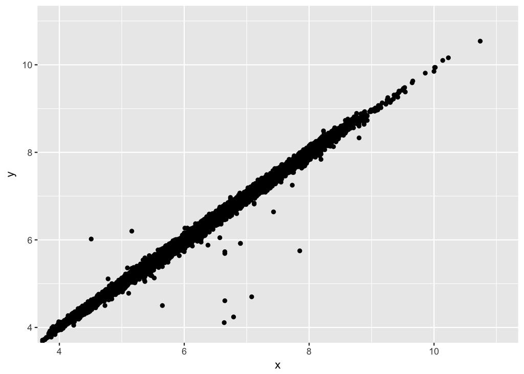

```r
ggplot(data = diamonds) +
  geom_point(mapping = aes(x = x, y = y)) +
  coord_cartesian(xlim = c(4, 11), ylim = c(4, 11))
```